# CNN based classification of Cat and Dog WITHOUT transfer learning: 95% validation accuracy

**Abstract**

The purpose of this script is to understand various stages of building a good CNN model. Using transfer learning techniques, one can achieve nearly 100% accuracy for this task. However, in this script I will try to build a model from scratch that leads a reasonable accuracy. The final result shows close to 95% on validation dataset.

Key highlights:

- Create a model from scratch without transfer learning.
- Gain insights on how the depth and width of the model affects the loss curve
- Create your own data feeder
- Write custom callbacks for saving best model or early stopper
- Prediction on any online/downloaded images

```python
import os
import zipfile
import random
import shutil
from shutil import copyfile
from os import getcwd
import pathlib
import datetime

import cv2
from PIL import Image


import tensorflow_datasets as tfds
import tensorflow as tf
from tensorflow import keras
from tensorflow.keras import layers
from tensorflow.keras.preprocessing import image_dataset_from_directory
from tensorflow.keras.preprocessing.image import ImageDataGenerator
from tensorflow.keras.optimizers import RMSprop, Adam, SGD
from tensorflow.keras.callbacks import TensorBoard
from tensorflow.keras.models import model_from_json
from sklearn.model_selection import train_test_split


import matplotlib.pylab as plt
import numpy as np

#Write twice, because sometimes it does not work the first time, especially if you are switching back to notebook
%matplotlib notebook
%matplotlib notebook
```

## Set path of the dataset

The images are under two folders, /Cat and /Dog. I do not wish to create separate train and validation folders and copy the images into it. Instead I will write a custom data feeder that will read images, perform preprocessing and feed to the model. We will perform on-the-fly augmentation within the model (by adding extra layers at the start).

```python
path_to_images = pathlib.Path('/CatsAndDogs/Pet_images_new')
Dogs_dir = os.path.join(path_to_images, 'Dog')
Cats_dir = os.path.join(path_to_images, 'Cat')

print(len(os.listdir(Dogs_dir)))
print(len(os.listdir(Cats_dir)))


dog_image_fnames = os.listdir(Dogs_dir)
cat_image_fnames = os.listdir(Cats_dir)
```

```
11663
11735
```

## Delete corrupted images

```python
num_skipped = 0
for folder_name in ("Cat", "Dog"):
    folder_path = os.path.join(path_to_images, folder_name)
    for fname in os.listdir(folder_path):
        fpath = os.path.join(folder_path, fname)
        try:
            fobj = open(fpath, "rb")
            is_jfif = tf.compat.as_bytes("JFIF") in fobj.peek(10)
        finally:
            fobj.close()

        if not is_jfif:
            num_skipped += 1
            # Delete corrupted image
            os.remove(fpath)

print("Deleted %d images" % num_skipped)
```

```
Deleted 0 images
```

```python
#remove 0 size images and non jpg images
import os

j=0
for catagory in os.listdir(path_to_images):
    sub_dir = os.path.join(path_to_images, catagory)
    for name in os.listdir(sub_dir):
        fpath = os.path.join(sub_dir,name)
        if name.split('.')[1] == 'jpg':
            if os.path.getsize(fpath) <= 0:
                if os.path.isfile(fpath) == False:
                    print(fpath)
                os.remove(fpath)
            elif os.path.getsize(fpath) > 0:
                j +=1
        if name.split('.')[1] != 'jpg':
            print(fpath)
            os.remove(fpath)
print(j)
```

```
23398
```

```python
#Count total images
image_count = len(list(path_to_images.glob('*/*.jpg')))
print(image_count)
```

```
23398
```

## Remove non- cat/dog images

After carefully inspecting the images, I found some images that are neither cats nor dogs. These images may cause the problems in training. If they appear in validation dataset, they may cause spikes in validation loss curve. Some examples are plotted below.

```python
path_bad_images = pathlib.Path("/CatsAndDogs/bad_images")
bad_images = os.listdir(path_bad_images)
print(len(bad_images))
```

```
11
```

[figure not shown]

```python
plt.figure(figsize=(8,8))
for i in np.arange(9):
    img = Image.open(os.path.join(path_bad_images,bad_images[i]))
    ax = plt.subplot(3, 3, i + 1)
    plt.imshow(img)
    #plt.title(class_names[labels[i]])
    plt.axis("off")
```

## Create data feeder

- Resize images
- define data split fraction
- batch size
- seed to shuffle and randomly dividing the training and validation dataset

```python
batch_size = 64  # max 1000 of these images can fit in gpu memory
new_img_size = (200,200)
data_split = 0.2 #0.0005
seed_value = 42

train_ds = tf.keras.preprocessing.image_dataset_from_directory(
    path_to_images,
    validation_split=data_split,
    subset="training",
    seed=seed_value,
    image_size=new_img_size,
    batch_size=batch_size)

val_ds = tf.keras.preprocessing.image_dataset_from_directory(
    path_to_images,
    validation_split=data_split,
    subset="validation",
    seed=seed_value,
    image_size=new_img_size,
    batch_size=batch_size)
```

```
Found 23398 files belonging to 2 classes.
Using 18719 files for training.
Found 23398 files belonging to 2 classes.
Using 4679 files for validation.
```

```python
class_names = train_ds.class_names
print(class_names)
```

```
['Cat', 'Dog']
```

## Inspect some images

Take 1 batch from the validation dataset and plot.

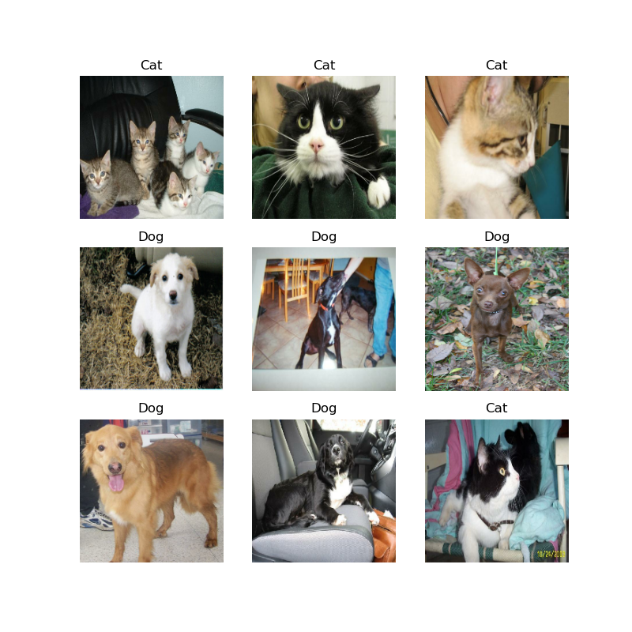

```python
plt.figure(figsize=(8,8))
for images, labels in val_ds.take(1):
    for i in range(9):
        ax = plt.subplot(3, 3, i + 1)
        plt.imshow(images[i].numpy().astype("uint8"))
        plt.title(class_names[labels[i]])
        plt.axis("off")
```

# Create model

Note also that, we have included on-the-fly image augmentation in the first two layers. Furthermore, we use dropout for regularization, to avoid over fitting. We do not want high dropout in the initial layers. It is set to a relatively higher value after flattening the convolution layer outputs.

And finally, since we are using ReLu activation function, using kernel_initializer='he_uniform' is highly recommended.

```python
#A shallow model
# model = tf.keras.models.Sequential([
#     tf.keras.layers.Conv2D(32, (3,3), activation='relu', input_shape=(new_img_size[0],new_img_size[1],3)),
#     tf.keras.layers.Conv2D(32, (3,3), activation='relu'),
#     tf.keras.layers.MaxPool2D(2,2),
#     tf.keras.layers.Conv2D(64, (3,3), activation='relu'),
#     tf.keras.layers.Conv2D(64, (3,3), activation='relu'),
#     tf.keras.layers.MaxPool2D(2,2),
#     tf.keras.layers.Conv2D(128, (3,3), activation='relu'),
#     tf.keras.layers.Conv2D(128, (3,3), activation='relu'),
#     tf.keras.layers.MaxPool2D(2,2),
#     tf.keras.layers.Flatten(),
#     tf.keras.layers.Dropout(0.3),
#     tf.keras.layers.Dense(256, activation='relu'),
#     tf.keras.layers.Dropout(0.3),
#     tf.keras.layers.Dense(256, activation='relu'),
#     tf.keras.layers.Dense(1, activation='sigmoid')
# ])

#Secind model with more layers
model = tf.keras.models.Sequential([
    layers.experimental.preprocessing.Rescaling(1./255,input_shape=(new_img_size[0],new_img_size[1],3)),
    tf.keras.layers.experimental.preprocessing.RandomFlip('horizontal'),
    tf.keras.layers.experimental.preprocessing.RandomRotation(0.3),

    tf.keras.layers.Conv2D(16, (3,3), activation='relu', kernel_initializer='he_uniform', padding='same'),
    tf.keras.layers.BatchNormalization(),
    tf.keras.layers.MaxPool2D(2,2),
    tf.keras.layers.Dropout(0.2),

    tf.keras.layers.Conv2D(32, (3,3), activation='relu', kernel_initializer='he_uniform', padding='same'),
    tf.keras.layers.BatchNormalization(),
    tf.keras.layers.MaxPool2D(2,2),
    tf.keras.layers.Dropout(0.2),

    tf.keras.layers.Conv2D(32, (3,3), activation='relu', kernel_initializer='he_uniform', padding='same'),
    tf.keras.layers.BatchNormalization(),
    tf.keras.layers.MaxPool2D(2,2),
    tf.keras.layers.Dropout(0.2),

    tf.keras.layers.Conv2D(64, (3,3), activation='relu', kernel_initializer='he_uniform', padding='same'),
    tf.keras.layers.BatchNormalization(),
    tf.keras.layers.MaxPool2D(2,2),
    tf.keras.layers.Dropout(0.2),

    tf.keras.layers.Conv2D(256, (3,3), activation='relu', kernel_initializer='he_uniform', padding='same'),
    tf.keras.layers.BatchNormalization(),
    tf.keras.layers.MaxPool2D(2,2),
    tf.keras.layers.Dropout(0.2),

    tf.keras.layers.Flatten(),
    tf.keras.layers.Dense(128, activation='relu', kernel_initializer='he_uniform'),
    tf.keras.layers.Dropout(0.35),
    #tf.keras.layers.BatchNormalization(),
    tf.keras.layers.Dense(1, activation='sigmoid')
])

# model = tf.keras.models.Sequential([
#     layers.experimental.preprocessing.Rescaling(1./255),
#     layers.Conv2D(32, 3, activation='relu'),
#     layers.MaxPooling2D(),
#     layers.Conv2D(32, 3, activation='relu'),
#     layers.MaxPooling2D(),
#     layers.Conv2D(32, 3, activation='relu'),
#     layers.MaxPooling2D(),
#     layers.Flatten(),
#     layers.Dense(128, activation='relu'),
#     layers.Dense(num_classes)
# ])

model.compile(optimizer=Adam(lr=0.001), loss='binary_crossentropy', metrics=['acc']) #SGD(lr=0.007, momentum=0.9), #RMSprop(lr=0.0001), #Adam(lr=0.001)
#model.compile(optimizer='adam', loss='binary_crossentropy', metrics=['acc'])

#print(model.summary())
```

## Create callbacks

```python
class MyThresholdCallback(tf.keras.callbacks.Callback):
    def __init__(self, threshold):
        super(MyThresholdCallback, self).__init__()
        self.threshold = threshold

    def on_epoch_end(self, epoch, logs=None):
        val_acc = logs["val_acc"]
        if val_acc >= self.threshold:
            self.model.stop_training = True

early_stopping_callback = MyThresholdCallback(threshold=0.951)

logdir = os.path.join(
    "logs", datetime.datetime.now().strftime("%Y%m%d-%H%M%S"))

modelfname = datetime.datetime.now().strftime("%Y%m%d-%H%M%S")+'.h5'
model_folder = pathlib.Path('/CatsAndDogs/model')
mcp_save = tf.keras.callbacks.ModelCheckpoint(os.path.join(model_folder, modelfname), save_best_only=True, monitor='val_loss', mode='min')

tensorboard_callback = tf.keras.callbacks.TensorBoard(logdir, histogram_freq=1)

print(logdir)
# # ======= Go to the logs folder within the current project. ===========
# # ======= Open a terminal, activate correct env, run following command to launch tensorboard
# # tensorboard --port=6007 --logdir /CatsAndDogs/logs
# # =====================================================================

epochs = 300
history = model.fit(
    train_ds,
    validation_data=val_ds,
    epochs=epochs,
    verbose=1,
    callbacks=[tensorboard_callback, mcp_save, early_stopping_callback]
)

#model.save(os.path.join(model_folder, modelfname))

# model.fit(
#   train_ds,
#   validation_data=val_ds,
#   epochs=3
# )
```

```
logs/20201022-232355
```

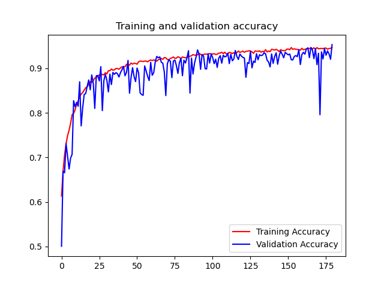

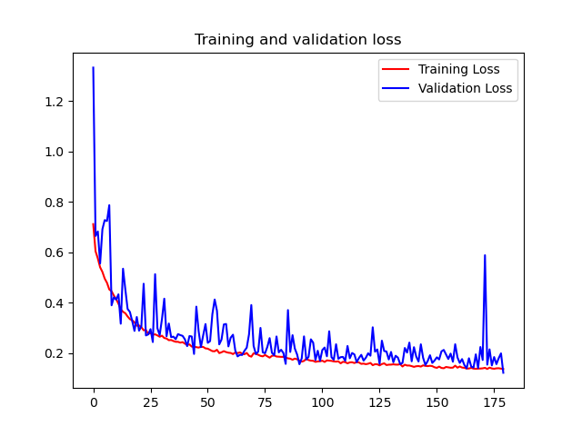

```python
# PLOT LOSS AND ACCURACY

#import matplotlib.image  as mpimg
#import matplotlib.pyplot as plt
#-----------------------------------------------------------
# Retrieve a list of list results on training and test data
# sets for each training epoch
#-----------------------------------------------------------
acc=history.history['acc']
val_acc=history.history['val_acc']
loss=history.history['loss']
val_loss=history.history['val_loss']

epochs=np.arange(len(acc)) # Get number of epochs

#------------------------------------------------
# Plot training and validation accuracy per epoch
#------------------------------------------------
plt.figure()
plt.plot(epochs, acc, 'r', label="Training Accuracy")
plt.plot(epochs, val_acc, 'b', label="Validation Accuracy")
plt.title('Training and validation accuracy')
plt.legend()
#------------------------------------------------
# Plot training and validation loss per epoch
#------------------------------------------------
plt.figure()
plt.plot(epochs, loss, 'r', label="Training Loss")
plt.plot(epochs, val_loss, 'b', label="Validation Loss")
plt.legend()

plt.title('Training and validation loss')

# Desired output. Charts with training and validation metrics. No crash :)
```

## Save and Load best model

```python
# serialize model to JSON
model_json = model.to_json()
with open(pathlib.Path("/CatsAndDogs/model/best_model_v2/model_structure.json"), "w") as json_file:
    json_file.write(model_json)
```

```python
# load json and create model
json_file = open(pathlib.Path("/CatsAndDogs/model/best_model_v2/model_structure.json"), 'r')
loaded_model_json = json_file.read()
json_file.close()

loaded_model = model_from_json(loaded_model_json)
# load weights into new model
loaded_model.load_weights(pathlib.Path("/CatsAndDogs/model/best_model_v2/20201022-232355.h5"))
print("Loaded model from disk")

# evaluate loaded model on test data
loaded_model.compile(loss='binary_crossentropy', optimizer='rmsprop', metrics=['accuracy'])
```

```
Loaded model from disk
```

# Predictions

## Test on validation set images

```
Prediction:  Cat  | Truth:  Cat
Score:  [0.]
```

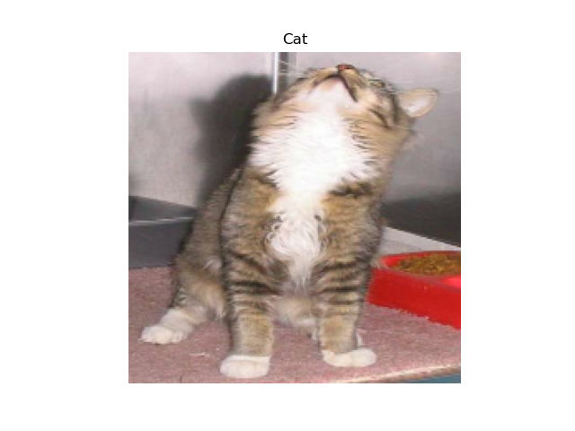

```
(-0.5, 199.5, 199.5, -0.5)
```

```python
for images, labels in val_ds.take(1):
    i = random.randint(0,10)

img_array = keras.preprocessing.image.img_to_array(images[i])
img_array = tf.expand_dims(img_array, 0)  # Create batch axis

true_class = np.array(labels[i])
predicted_class = model.predict_classes(img_array)[0]
predictions = model.predict(img_array)
score = predictions[0]

print("Prediction: ",class_names[predicted_class[0]], " | Truth: ", class_names[true_class])
print("Score: ", np.round(score,2))

plt.figure()
plt.imshow(images[i].numpy().astype("uint8"))
plt.title(class_names[true_class])
plt.axis("off")
```

## Test on online/downloaded images

```
Prediction:  Cat  | Truth:  Cat
Score:  [0.]
```

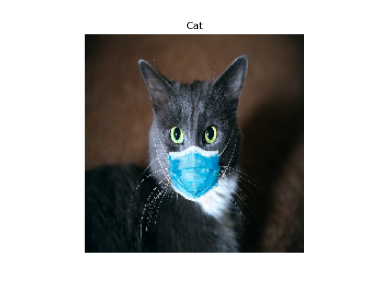

```
(-0.5, 199.5, 199.5, -0.5)
```

```python
i=0
img_name = r"Coronavirus-and-Cats-Science-Roundup-Catipilla.jpg"
path_to_Downloaded_images = pathlib.Path("/CatsAndDogs/online_test_images")
img_file_path = os.path.join(path_to_Downloaded_images,img_name)

img = keras.preprocessing.image.load_img( img_file_path, target_size=new_img_size)

img_array = keras.preprocessing.image.img_to_array(img)
img_array = tf.expand_dims(img_array, 0)  # Create batch axis

predicted_class = loaded_model.predict_classes(img_array)[0]
predictions = loaded_model.predict(img_array)
score = predictions[0]

print("Prediction: ",class_names[predicted_class[0]], " | Truth: ", class_names[i])
print("Score: ", np.round(score,2))

plt.figure()
plt.imshow(img)
plt.title(class_names[i])
plt.axis("off")
```

# Conclusions